# Homework 3

## C) Create a scatter plot of the crime rates and the median home values for:

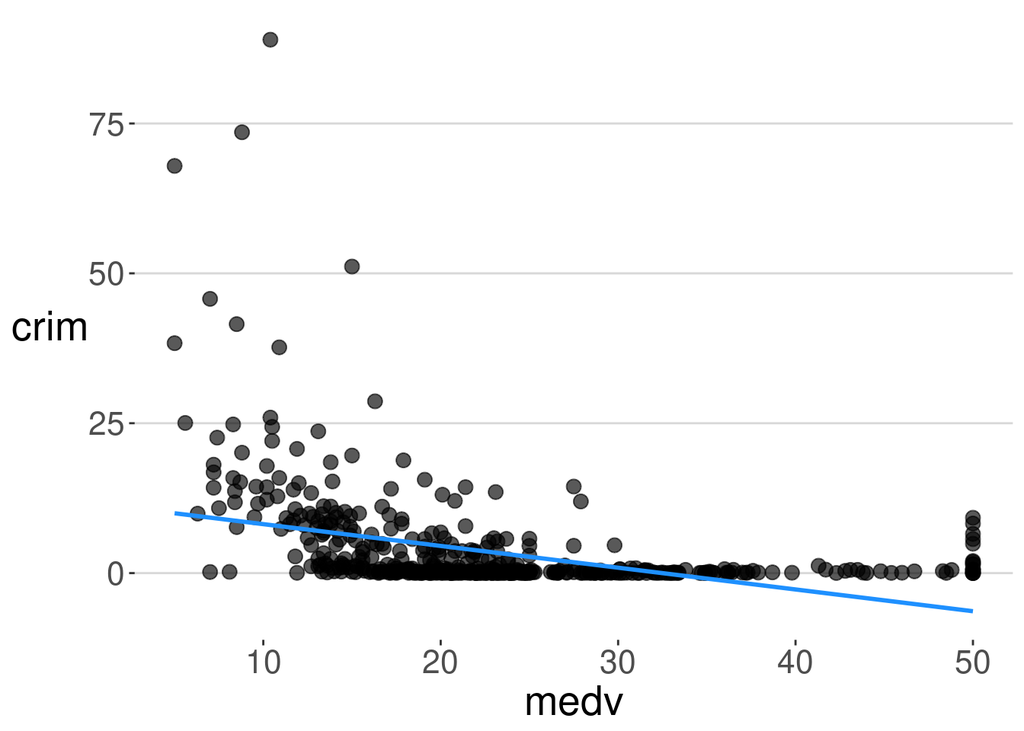

```r
Boston <- Boston |>
    mutate(charles_river = ifelse(chas==1, " Bounds River",
                                  "Does not Bound River"))


Boston |>
  ggplot(aes(x=medv, y=crim)) +
  geom_point(size=3, alpha=.65, ) + # modifies size & color of dots
  geom_smooth(method='lm', color="dodgerblue", se=FALSE, size=1) +
  theme(text=element_text(size=20))  # changes font size
```

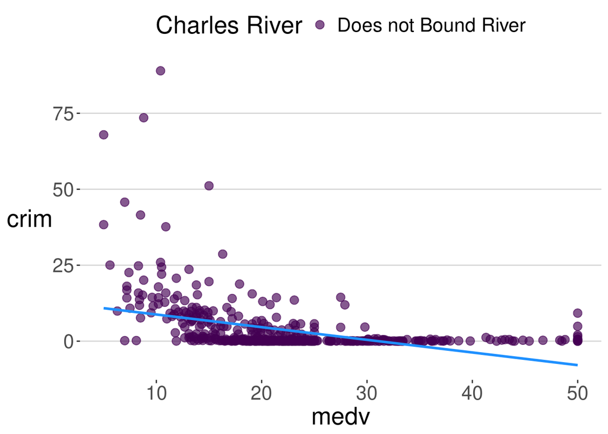

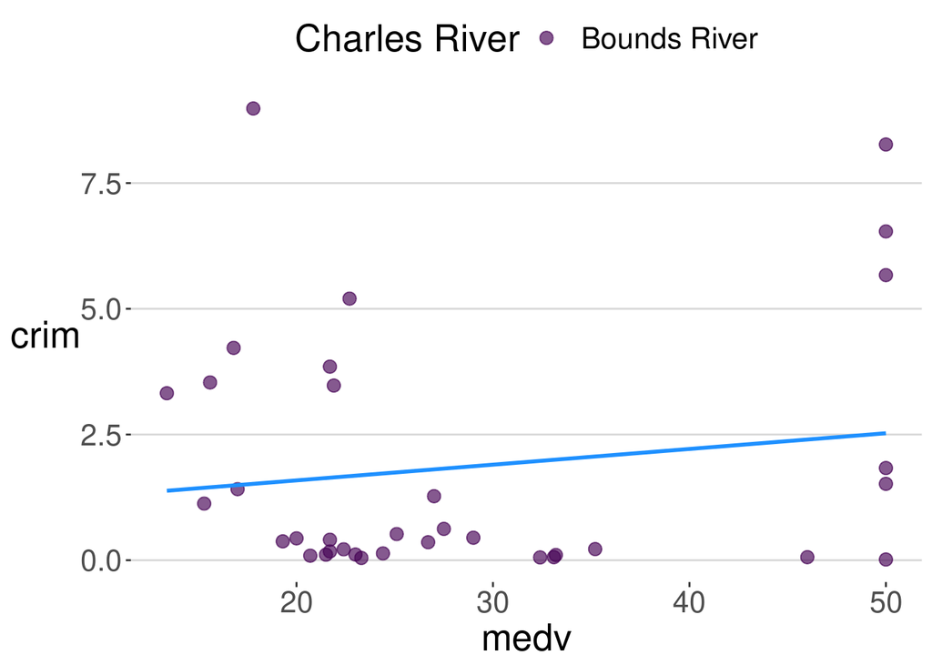

```r
# we can use a map function to produce scatterplots
## for different subsets of the data so we do not repeat the code
Boston |>
  group_by(chas) |>
  group_map(~ .x |>
     ggplot(aes(x=medv, y=crim, color=charles_river)) +
  geom_point(size=3, alpha=.65, ) +
  geom_smooth(method='lm', color="dodgerblue", se=FALSE, size=1) +
  theme(text=element_text(size=20), legend.position="top") +
  scale_color_viridis_d(option="D", end=.8) +
  labs(color='Charles River')

  )
```

## D) Analyze the crime rates as a function of median home values in a simple linear regression with an intercept.

- Report what the regression coefficients mean in lay terms.
  - For every one unit increase in a suburb’s median home value, crime rates drop .36 , or less than 1 crime, per 1000. For suburbs with a median home value of $0 the expected average crime rate is 11.8 per 1000.

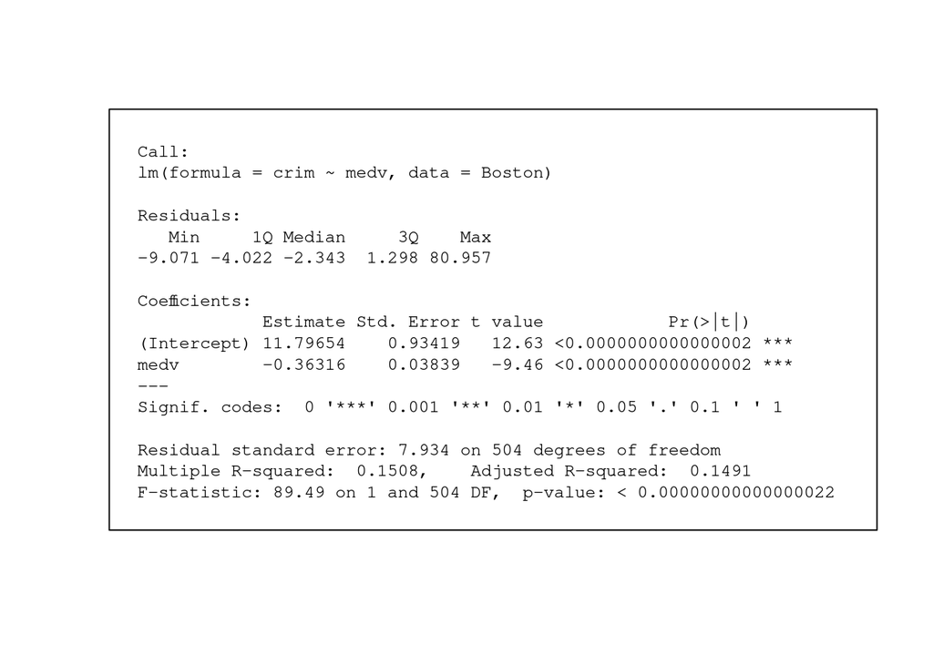

```r
mod_1 <- lm(crim ~ medv, Boston)
print_output(summary(mod_1))
```

## E) Calculate the coefficients reported in D as well as their standard errors by hand.

$$\hat{\beta}_1=\dfrac{\sum(x_i-\bar{x})(y_i-\bar{y})}{\sum(x_i-\bar{x})^2}\equiv\dfrac{SS_{XY}(n-1)^{-1}}{SS_{X}(n-1)^{-1}}=\dfrac{s_{XY}}{s_{XX}}$$

- where

$$s_{XY}=\dfrac{\sum(x_i-\bar{x})(y_i-\bar{y})}{n-1}$$

- and
  $$s_{XX}=\dfrac{\sum(x_i-\bar{x})^2}{n-1}$$

$$\hat{\beta}_0=\bar{y}-\hat{\beta}_1\bar{x}$$

- First, we will add predictions, residuals, and mean differences to our Boston data set as new columns for ease of computation.

```r
Boston <- Boston |>
  as_tibble() |>
  mutate(mean_diff_medv = medv - mean(medv),
         mean_diff_crim = crim - mean(crim),
         SS_XY = mean_diff_medv * mean_diff_crim,
         SS_X = mean_diff_medv^2) |>
  mutate(across(where(is.double), ~ round(.x, 2))) # rounds the new columns

Boston |>
  select(crim, medv,
         starts_with("mean"), starts_with("SS")) |>
  slice_sample(n=6) |>  # print N random rows
  kable()
```

| crim | medv | mean_diff_medv | mean_diff_crim | SS_XY | SS_X |
| --- | --- | --- | --- | --- | --- |
| 4.75 | 14.1 | -8.43 | 1.14 | -9.60 | 71.11 |
| 0.14 | 17.4 | -5.13 | -3.48 | 17.85 | 26.35 |
| 0.18 | 7.0 | -15.53 | -3.43 | 53.28 | 241.27 |
| 0.25 | 14.4 | -8.13 | -3.36 | 27.32 | 66.14 |
| 0.03 | 34.7 | 12.17 | -3.59 | -43.63 | 148.04 |
| 0.64 | 18.2 | -4.33 | -2.98 | 12.89 | 18.77 |

- We can now calculate our regression coefficients with the equations above.

```r
Boston_betas <- Boston |>
  summarise(Beta_0 = mean(crim - mean(medv) * sum(SS_XY) / sum(SS_X)),
            Beta_1 = sum(SS_XY) / sum(SS_X))

Boston_betas |> kable()
```

| Beta_0 | Beta_1 |
| --- | --- |
| 11.79643 | -0.3631598 |

- Since we computed the beta coefficients, we can compute predictions by hand and add them to the data frame. We will distinguish the new columns we compute by hand with “**_2**” to compare with those we extracted from the linear model.
  - Note. Our calculations by hand for the model predictions and residuals are identical to what we extracted from the model.

```r
Boston <- Boston |>
  mutate(# add predictions from the model
         mod_predictions = predict(mod_1),
         # predict by hand
         mod_predictions_2 = Boston_betas$Beta_0 + Boston_betas$Beta_1*medv,

         # also add residuals from the model
         mod_residuals = resid(mod_1),
         # which is the same if we subtract observed from predicted
         mod_residuals_2 = crim - mod_predictions,
         across(where(is.double), ~ round(.x, 2)))

Boston |>
  select(crim, starts_with("mod")) |>
  slice_sample(n=6) |> # select a random draw of suburbs to print
  kable()
```

| crim | mod_predictions | mod_predictions_2 | mod_residuals | mod_residuals_2 |
| --- | --- | --- | --- | --- |
| 0.25 | 4.61 | 4.61 | -4.36 | -4.36 |
| 28.66 | 5.88 | 5.88 | 22.78 | 22.78 |
| 0.23 | 5.77 | 5.77 | -5.54 | -5.54 |
| 9.82 | 6.97 | 6.97 | 2.86 | 2.85 |
| 0.04 | 3.81 | 3.81 | -3.77 | -3.77 |
| 0.09 | 4.35 | 4.35 | -4.26 | -4.26 |

- We can continue our hand calculations for beta coefficient standard errors since we calculated by hand model predictions and residuals, and verified them with model estimates above.

```r
Boston <- Boston |>
  # we need to take squared deviations of the residuals
  mutate(sq_medv_resid = mod_residuals_2^2)

# we can also save out the number of parameters from the model for computation
num_param <- length(mod_1$coefficients)


Boston_betas <- Boston |>
  summarise(Beta_0 = mean(crim - mean(medv) * sum(SS_XY) / sum(SS_X)),
            Beta_1 = sum(SS_XY) / sum(SS_X),
            h_sigma_sq_medv = sum(sq_medv_resid) / (n() - num_param),

            # calculate SE for intercept
            Beta_0_se = sqrt(h_sigma_sq_medv *
               (1/n() + mean(medv)^2/sum(SS_X))),

            # calculate SE for slope
            Beta_1_se = sqrt(h_sigma_sq_medv / sum(SS_X))
  ) |>
  select(Beta_0, Beta_1, Beta_0_se, Beta_1_se) |>
  pivot_longer(everything()) |>
  rename(coeff=name) |>
  mutate(coeff_type =
           ifelse(str_detect(coeff, "se"), "Std. Error", "Estimate"),
         coeff = str_remove(coeff, "_se"),
         coeff = case_when(
           coeff == "Beta_0" ~ "Intercept",
           coeff == "Beta_1" ~ "medv"
         )) |>
  pivot_wider(names_from = coeff_type, values_from = value)

Boston_betas |> kable()
```

| coeff | Estimate | Std. Error |
| --- | --- | --- |
| Intercept | 11.7964278 | 0.9342150 |
| medv | -0.3631598 | 0.0383912 |

## F) Create a scatter plot of the crime rates and the median home values with a regression line.

- Is the regression line a good summary of the crime rates? Examine residuals to assess this.
  - The regression line does not seem to fit the data well, suggesting that the line of best fit does not minimize residuals, particularly for suburbs with lower median home values and high crime rates. Moreover, the regression line predicts negative crime rates for suburbs with higher median home values.
  - Summary statistics on model residuals shows that errors have a zero error mean. However, our histogram and density plot shows that our residuals are not normally distributed (right-skewed); thus, violating the assumption of normality of errors which we also examined with a qqplot which supports this observation.

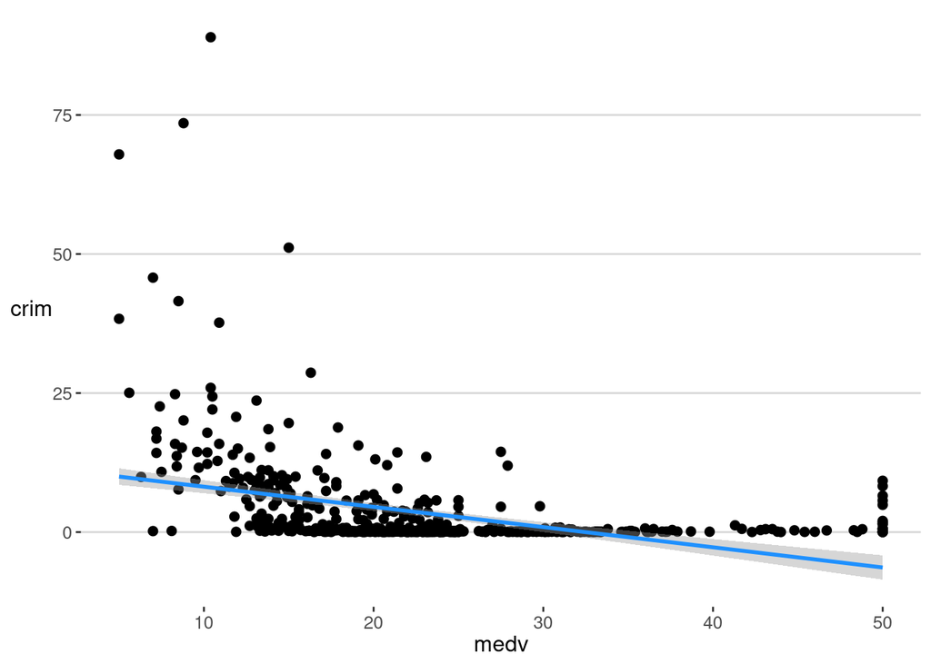

```r
Boston |>
  ggplot(aes(y=crim, x=medv)) +
  geom_point(size=2)+
  geom_smooth(method='lm', color="dodgerblue", se=TRUE, size=1)
```

```r
Boston |>
  select(mod_residuals) |>
  summary() |>
  kable()
```

|  | mod_residuals |
| --- | --- |
|  | Min. :-9.07000 |
|  | 1st Qu.:-4.02500 |
|  | Median :-2.34000 |
|  | Mean : 0.00012 |
|  | 3rd Qu.: 1.30000 |
|  | Max. :80.96000 |

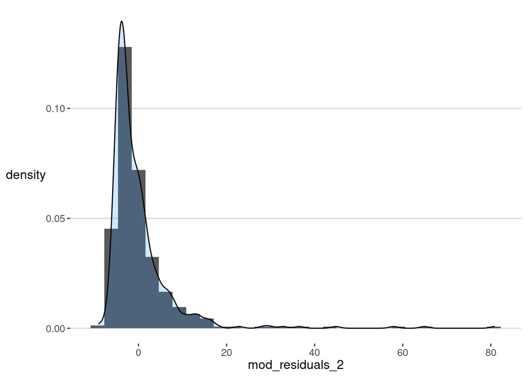

```r
Boston |>
  ggplot(aes(x=mod_residuals_2)) +
  geom_histogram(aes(y=..density..)) +
  geom_density(fill="dodgerblue", alpha=.2)
```

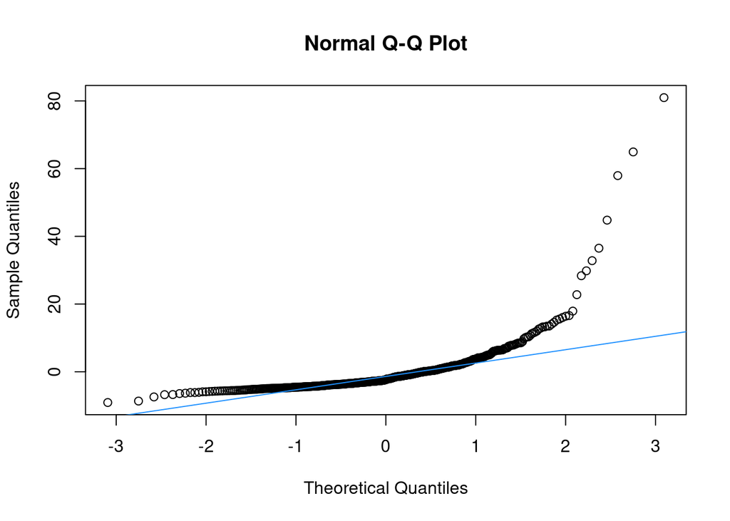

```r
qqnorm(Boston$mod_residuals_2)
qqline(Boston$mod_residuals_2, col="dodgerblue")
```

## G) Create a scatter plot of predicted crim (x-axis) and residuals (y-axis).

- What do you observe?
  - Data points are not scattered or centered around zero. There is a pattern i.e. not spread randomly around zero for predicted values.

    We observe a pattern in residuals suggesting that we do not satisfy the assumption of equal variance of errors or homoscedasticity. We observe unequal error variance called heteroscedasticity which can be an issue for predicting valeus.

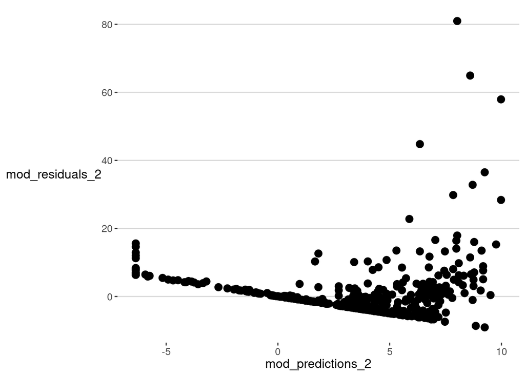

```r
Boston |>
  ggplot(aes(x=mod_predictions_2, y=mod_residuals_2)) +
  geom_point(size=3)
```

## Footnotes

[^1]: Note. Upon some digging, for the Boston data crime rates are calculated as $\frac{reported \space crimes}{suburb \space population} \times 1000$. Therefore, we interpret the crime incidence in these data as per 1000.